# Part2 - TIGeR bioinformatics interview assignment

Daniel Stratis

2024-07-18

## SNP analysis

This script summarizes and visualizes the distribution of unique SNPs for multiple VCF files.

### Table of contents:

**1. Present unique SNP calls**

**2. Summarize unique SNP characteristics**

**3. Create a visualization for a unique SNP characteristic**

### Load packages

```r
#install packages
package_names = c("dplyr","vcfR","ggplot2","ggpubr")
for (package_name in package_names){
    #if package is not installed, install it
    if (!requireNamespace("dplyr", quietly = TRUE)){
        install.packages("dplyr")
    }
}

#load packages
library(dplyr)
library(vcfR)
library(ggplot2)
library(ggpubr)
```

### Load data

```r
#define global variables
DIR = "C:/Users/dstra/Nextcloud/Documents/Computers/Code/Github repos/bioinformatics analyses/Variant calling/TIGeR_assignment/filtered_vcfs"

#set working directory
setwd(DIR)

#load the data
vcf_files = list.files(path = ".", pattern = '\\.vcf.gz$', full.names = TRUE)

#define an empty list
vcf_data = list()
for (vcf_file in vcf_files){
    #load VCF file
    vcf = read.vcfR(vcf_file, verbose = FALSE)
    vcf_data[[vcf_file]] = data.frame(vcf@fix)
}
```

### 1. Present unique SNP calls

```r
#define an empty list and data frame
vcf_unique = list()
vcf_summary = data.frame()
for (vcf_file in vcf_files){
    #define VCF data for current sample
    vcf_df = vcf_data[[vcf_file]]

    #total number of variants
    total_variants = nrow(vcf_df)

    #number of variants passing filter
    vcf_df = filter(vcf_df, FILTER == 'PASS')
    passed_variants = nrow(vcf_df)

    #number of variants removed
    failed_variants = total_variants - passed_variants

    #number of unique variants
    vcf_df = vcf_df %>%
        select(CHROM, POS, REF, ALT) %>%
        distinct()
    unique_variants = nrow(vcf_df)

    #store the results
    summary = data.frame(sample = vcf_file, total_variants, failed_variants, passed_variants, unique_variants)
    vcf_summary = rbind(vcf_summary, summary)
    vcf_unique[[vcf_file]] = vcf_df
}
```

```r
#display the results
print(vcf_summary)
```

```
##                                               sample total_variants
## 1 ./HG005_MRG_35x.hard-filtered_snps_filtered.vcf.gz         107250
## 2 ./HG006_MRG_35x.hard-filtered_snps_filtered.vcf.gz         107882
##   failed_variants passed_variants unique_variants
## 1            2705          104545          104545
## 2            2196          105686          105686
```

Sample HG005 contained 107,250 variants, of which 2,705 were removed due to low PHRED quality scores or read-depth. From the remaining 104,545 variants passing quality control, 104,545 were unique variants.

Sample HG006 contained 107,882 variants, of which 2,196 were removed due to low PHRED quality scores or read-depth. From the remaining 105,686 variants passing quality control, 105,686 were unique variants.

### 2. Summarize unique SNP characteristics

#### Distribution of variant types (transitions vs transversions)

```r
#function to determine if a variant is a transition or transversion mutation
classify_variant = function(ref, alt){
  #define purines and pyrimidines
  purines <- c("A", "G")
  pyrimidines <- c("C", "T")

  #if the variant is a transition
  if (ref %in% purines && alt %in% purines || ref %in% pyrimidines && alt %in% pyrimidines){
    return("transition")

  #if the variant is a transversion
  } else if (ref %in% purines && alt %in% pyrimidines || ref %in% pyrimidines && alt %in% purines){
    return("transversion")
  } else {
    return("other")
  }
}
```

```r
#define an empty data frame
variant_types = data.frame()
for (vcf_file in vcf_files){
  #define VCF data for current sample
  vcf_df = vcf_unique[[vcf_file]]

  #define the function inputs
  ref = vcf_df$REF
  alt = vcf_df$ALT

  #determine each variant type
  variant_classes = mapply(classify_variant, ref, alt)

  #count the number of transition and transversion variants
  n_transitions = sum(variant_classes == 'transition')
  n_transversions = sum(variant_classes == 'transversion')
  ratio = n_transitions / n_transversions

  #store the results
  summary = data.frame(sample = vcf_file, n_transitions, n_transversions, ratio)
    variant_types = rbind(variant_types, summary)
}
```

```r
#display the results
print(variant_types)
```

```
##                                               sample n_transitions
## 1 ./HG005_MRG_35x.hard-filtered_snps_filtered.vcf.gz         71096
## 2 ./HG006_MRG_35x.hard-filtered_snps_filtered.vcf.gz         71679
##   n_transversions    ratio
## 1           33420 2.127349
## 2           33978 2.109571
```

The distribution of transition and tranversion mutations does not differ between samples. However, within a sample the number of transition and transversion SNPs differ with more than double the number of transition mutations compared to transversion SNPs.

#### Distribution of variants across chromosomes

```r
#define an empty list
vcf_chrom = list()
for (vcf_file in vcf_files){
    #define VCF data for current sample
    vcf_df = vcf_unique[[vcf_file]]

    #count the number of variants in each chromosome
    chrom_result = vcf_df %>%
        group_by(CHROM) %>%
        summarize(count = n())

    #store the results
    vcf_chrom[[vcf_file]] = chrom_result
}
#display the result
str(vcf_chrom)
```

```
## List of 2
##  $ ./HG005_MRG_35x.hard-filtered_snps_filtered.vcf.gz: tibble [24 × 2] (S3: tbl_df/tbl/data.frame)
##   ..$ CHROM: chr [1:24] "chr1" "chr10" "chr11" "chr12" ...
##   ..$ count: int [1:24] 6804 6042 5254 5188 5168 2514 3612 8165 2277 842 ...
##  $ ./HG006_MRG_35x.hard-filtered_snps_filtered.vcf.gz: tibble [24 × 2] (S3: tbl_df/tbl/data.frame)
##   ..$ CHROM: chr [1:24] "chr1" "chr10" "chr11" "chr12" ...
##   ..$ count: int [1:24] 7178 5941 5103 4946 5419 1830 4062 8087 2299 820 ...
```

### 3. Create visualization for unique SNP characteristic

#### Distribution of variants across chromosomes

```r
#define an empty list
plots = list()
for (vcf_file in vcf_files){
  #define the data for current sample
  chrom_result = vcf_chrom[[vcf_file]]

  #define the order of chromosomes
  chrom_order = c(paste0('chr', 1:22), 'chrX', 'chrY')
  chrom_result$CHROM = factor(chrom_result$CHROM, levels = chrom_order)

  #create the plot
  plots[[vcf_file]] = ggplot(data = chrom_result, aes(x = CHROM, y = count)) +
  geom_bar(stat = 'identity') +
  labs(title = paste0('Distribution of variants across chromosomes\n', vcf_file),
    x = 'chromosome',
    y = 'variant counts') +
  theme_classic() +
  theme(axis.text.x = element_text(angle = 45, hjust = 1))
}
```

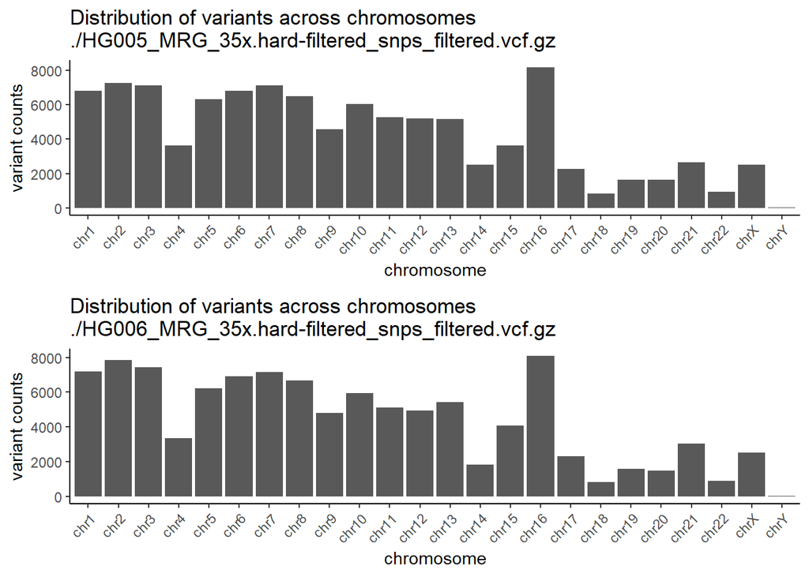

```r
#display the plots
ggarrange(plotlist = plots, ncol = 1)
```

Comparing between samples shows a similar distribution of variant counts across chromosomes.

Comparing variant counts between chromosome within a sample is not accurate. These counts must be normalized for chromosome size because a larger chromosomes will result in more variants.